# Bayesian Lasso Gibbs Sampler

Yuhao Li

# load data

```r
set.seed(10)
library(lars)
library("Matrix")
library(here)
data("diabetes")
```

# Q1 Simulate dataset

1 simulate X with N(0,1) density with 100 sample 2 create sparse vector based on proprtion of zero, non-zero value is simulated by N(0,1)

```r
# Set initial parameter
sample_size=100
p = 5
proportion_sparse = 0.5
sigma = 1
mean = 0

# Create Simulated y value
simulate = function(X,beta,mean,sigma,sample_size)
{
  y = X %*% beta + rnorm(sample_size,mean,sigma^2)
  return(y)
}

# Create a Sparse Vector for beta
createSparseVector = function(proportion_sparse,size)
{
  vec = rep(0,size)
  non_zero_num = proportion_sparse*size
  non_zero_value = rnorm(proportion_sparse*size)
  non_zero_entry = sample(1:size,non_zero_num)
  vec[non_zero_entry] = non_zero_value
  return(vec)
}

# Without Intercept
# Create X
X = matrix(rnorm(sample_size*p), ncol=p)
# scale X
X = scale(X)

# Create a random generated sparse vector
beta = createSparseVector(proportion_sparse,p)

# Get corresponding y
y = simulate(X,beta,mean,sigma,sample_size)
y = y - mean(y)


beta
```

```
[1]  0.0000000 -0.6800096  0.8694750  0.0000000  0.0000000
```

## Question 2 Fit dataset with lasso regression

Optimal Lambda

```r
library(glmnet)
# Choose optimal lambda
optimal_lasso_regression = function(lambda,X,y)
{
  lambda = cv.glmnet(X,y,alpha=1)
  lasso_model <- glmnet(X,y, alpha = 1, lambda = lambda$lambda.min)
  return(lasso_model)
}

# Choose given lambda
fixed_lasso_regression = function(lambda,X,y)
{
  lasso_model <- glmnet(X,y, alpha = 1, lambda = lambda)
  return(lasso_model)
}

lasso_model = optimal_lasso_regression(lambda,X,y)
lasso_model$beta[,1]
```

```
           V1            V2            V3            V4            V5
 0.0000000000 -0.7885680019  0.7435484575  0.0000000000  0.0000950313
```

## Choose lambda that some of regression coefficients are fitted to be 0

## Larger lambda will have larger chance to get 0

```r
lambda = 0.01
current_beta = c()
while(is.element(0,current_beta) == FALSE)
{
  lasso_model = fixed_lasso_regression(lambda,X,y)
  current_beta = lasso_model$beta[,1]
  lambda = lambda * 10
}
current_beta
```

```
        V1         V2         V3         V4         V5
 0.0000000 -0.7848248  0.7398053  0.0000000  0.0000000
```

```r
lambda
```

```
[1] 1
```

## Question 3 and 4 Gibbs for Bayesian Lasso

Derivation A is diagonal matrix contain a_1,…a_p $$
$$\begin{align*}
p(\beta |y,\sigma^2,a):
MVN((X^TX+\lambda^2A^{-1})^{-1}X^Ty,(X^TX+\lambda^2A^{-1})^{-1}\sigma^2)\\
p(\sigma^2
|y,\beta,a_j):InverseGamma(\frac{n}{2}+\frac{p}{2}+a,\frac{||y-X\beta||_2^2}{2}+\frac{\lambda^2\sum_j{\beta_j^2}}{2a_j}+b)\\
p(a_j|y,\beta,\sigma^2): GIG(1,\frac{\beta_j^2\lambda^2}{\sigma^2},1/2)
\end{align*}$$
$$

Gibbs Sampler

```r
library(LaplacesDemon)
library(ghyp) # gig
library(MASS) # Ginv


# Gibbs function
gibbs.f2=function(X, y, lambda, max.steps = 10^3){
    n <- nrow(X)
    p <- ncol(X)


  # Record sampling values
    betaSamples <- matrix(0, max.steps+1, p)
    sigma2Samples <- rep(0, max.steps+1)
    a_j_Samples <- matrix(0, max.steps+1, p)

    # Initialize
    betaSamples[1,] = 0
    sigma2Samples[1] = 1
    a_j_Samples[1,] = 1

    lambda = lambda #2
    a = 1 # Prior parameter for sigma2
    b = 2 # Prior parameter for sigma2
    t = max.steps

    for(i in 2:(t+1)) {
      A = diag(a_j_Samples[i-1,])
      # Sample beta
      mean_beta = solve(t(X)%*%X+lambda^2*solve(A))%*%t(X)%*%y
      variance_beta = solve(t(X)%*%X+lambda^2*solve(A))*sigma2Samples[i-1]
      variance_beta=round(variance_beta,10)
      betaSamples[i,] = rmvn(1,as.vector(mean_beta),variance_beta)

      # Sample sigma2
      sigma2Samples[i] = rinvgamma(1,n/2+p/2+a,(sum((y-X%*%betaSamples[i,])^2))/2 + sum(betaSamples[i,]^2/a_j_Samples[i-1,])*lambda^2/2+b)

      # Sample aj
      for (j in 1:p)
      {
        a_j_Samples[i,j] = rgig(1, 1,betaSamples[i,j]^2*lambda^2/sigma2Samples[i], 1/2)
      }
    }

    return(list(beta = betaSamples,sigma2 = sigma2Samples,a = a_j_Samples))
}
Samples = gibbs.f2(X,y,lambda)
```

Question 5 Plot Denstiy Plots for each $\beta_j$

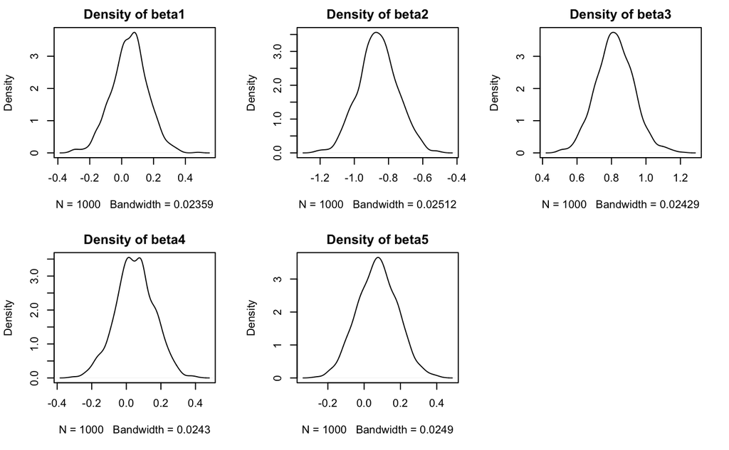

```r
par(mfrow=c(2,3))
for (j in 1:p)
{
     d <- density(Samples$beta[,j][-1]) # returns the density data
   plot(d,main=paste0("Density of beta",j))
}
```

```r
current_beta
```

```
        V1         V2         V3         V4         V5
 0.0000000 -0.7848248  0.7398053  0.0000000  0.0000000
```

# E-step derivation

$$Q(\theta,\theta^{(t)}) =
-(\frac{n}{2}+\frac{p}{2}+a+1)log(\sigma^2)-\frac{b}{\sigma^2}-\frac{||y-X\beta||_2^2}{2\sigma^2}-\frac{\lambda^2}{2\sigma^2}\sum_{j=1}^{p}(\beta_j^2
E[\frac{1}{a_j}])\\
E[\frac{1}{a_j}] = \frac{\sigma^{(t)}}{|\beta_j^{(t)}|\lambda}$$
# M-step
$$\frac{\partial Q}{\partial\beta}=0 \to \hat{\beta} =
(X^TX+\lambda^2\hat{A})^{-1}X^Ty\\
\hat{A}_{jj} = \begin{bmatrix}
\frac{\hat{\sigma}}{|\beta_j|\lambda}
\end{bmatrix}\\
\frac{\partial Q}{\partial\sigma^2}=0\to
\hat{\sigma^2}=\frac{\frac{||y-X\beta||_2^2+\lambda^2\beta^TA\beta}{2}+b}{\frac{n+p}{2}+a+1}$$

```r
# calculating multivariate normal distribution
library(mvtnorm)
bayesianLassoEM = function(X,y,beta.init,sigma2.init,epsilon = 1e-3,max.iter = 100,a,b,lambda)
{
  sigma2.curr = sigma2.init
  beta.curr = beta.init
  A.curr = diag(as.vector(sqrt(sigma2.curr)/(lambda*as.vector(abs(beta.curr)+1.0e-8))))

  # Store incomplete log-likelihoods for each iteration
  log_like = c()
  log_like = c(log_like,compute_ll(X,y,beta.init,sigma2.init,lambda,a,b,A.curr))
  delta.ll = 1
  err = 1
  n.iter = 1

  while((err>epsilon)&(n.iter<=max.iter))
  {
    # Record old value of theta
    vtheta_old <- c(beta.curr,sigma2.curr,A.curr)
    # EM step: Replace current value with new parameter estimate
    param = EM_step(X,y,beta.curr,sigma2.curr,lambda,a,b)
    beta.curr = param$beta.curr
    sigma2.curr = param$sigma2.curr
    A.curr = param$A.curr
    vtheta <- c(beta.curr,sigma2.curr,A.curr)
    # incomplete log-likelihoods with new value
    log_like = c(log_like,compute_ll(X,y,beta.curr,sigma2.curr,lambda,a,b,A.curr))
    # change in value of theta
    err <- max(abs(vtheta - vtheta_old))
    # compute change of log-likelihoods
    delta.ll = log_like[length(log_like)]-log_like[length(log_like)-1]
    # increase number of iteration
    n.iter = n.iter + 1

  }

  print(n.iter)
  print(log_like)
  print(err)
  return(list(beta = beta.curr,sigma2 = sigma2.curr))
}

# compute incomplete log likelihood value
compute_ll = function(X,y,beta,sigma2,lambda,a,b,A)
{

  n = dim(X)[1]
  p = dim(X)[2]
  ll = -(n/2+p/2+a+1)*log(sigma2) - norm(y-X%*%beta,'2')^2/(2*sigma2)-lambda^2/(2*sigma2)*(t(beta)%*%A%*%beta)-b/sigma2
  return(ll)
}

# E-step and M-step
EM_step = function(X,y,beta,sigma2,lambda,a,b)
{
  # Estimate E[1/a_j] and build matrix
  # E-step
  A.curr = diag(sqrt(as.vector(sigma2))/(lambda*as.vector(abs(beta)+1.0e-8)))
  n = dim(X)[1]
  p = dim(X)[2]

  # Calculate new beta and new sigma2
  # M-step
  beta.curr = solve(t(X)%*%X+lambda^2*A.curr)%*%(t(X)%*%y)
  sigma2.curr = (norm(y-X%*%beta,'2')^2/2+lambda^2*(t(beta)%*%A.curr%*%beta)/2+b)/(n/2+p/2+a+1)
  return(list(beta.curr = beta.curr,sigma2.curr = sigma2.curr,A.curr = A.curr))
}

lam = lasso_model$lambda
output = bayesianLassoEM(X,y,beta.init = rep(1,p),sigma2.init=1,epsilon = 1e-3,max.iter = 100,a=1,b=2,lambda=lam)
```

```
[1] 8
[1] -341.78002 -109.64486  -59.98291  -59.86175  -59.86136  -59.86136  -59.86136
[8]  -59.86136
[1] 6.042179e-05
```

```r
beta
```

```
[1]  0.0000000 -0.6800096  0.8694750  0.0000000  0.0000000
```

# Variational bayes

Assume optimal densities are from mean field families
$$q(\beta,\sigma^2,a) = q(\beta)q(\sigma^2)q(a)$$
where
$$q_{\beta^*}(\beta) \propto
exp[E_{a,\sigma^2}\{log(p(\beta|\sigma^2,a)\}]\\
q_{\sigma^{2*}}(\sigma^2) \propto
exp[E_{\beta,a}\{log(p(\sigma^2|\beta,a)\}]\\
q_{a^*}(a) \propto exp[E_{\sigma^2,\beta}\{log(p(a|\sigma^2,\beta)\}]\\$$

```r
bayesian_lasso_mfvb <- function(vy, mX, lambda, sigma2_hat)
{
  MAXITER <- 500
  TOL <- 1.0E-8
  lambda2 <- lambda*lambda
  a <- 0.0001
  b <- 0.0001
  n <- nrow(mX)
  p <- ncol(mX)
  XTX <- t(mX)%*%mX
  XTy <- t(mX)%*%vy
  vmu_til  <- matrix(0,p,1)
  mSigma_til <- diag(1,p)
  a_til <- a + 0.5*(n + p)
  b_til <- sigma2_hat*a_til
  vd <- rep(1,p)
  vtheta <- c(vmu_til,mSigma_til,a_til, b_til)

  for (ITER in 1:MAXITER)
  {
    # M-step
    mQ <- solve(XTX + lambda2*diag(vd),tol=1.0E-99)
    vmu_til    <- mQ%*%XTy
    mSigma_til <- (b_til/a_til)*mQ
    vsigma2_til <- diag(mSigma_til)
    a_til <- a + 0.5*(n + p)
    b_til <- b + 0.5*sum((vy - mX%*%vmu_til)^2) + 0.5*lambda2*sum(vd*vmu_til*vmu_til) + 0.5*sum(diag(mQ%*%mSigma_til))

    # E-step
    vd <- sqrt(b_til/(a_til*(vmu_til^2 + vsigma2_til)))/lambda
    vd <- as.vector(vd)
    vtheta_old <- vtheta
    vtheta <- c(vmu_til,mSigma_til,a_til, b_til)
    err <- max(abs(vtheta - vtheta_old))
    cat("ITER=",ITER,"err=",err,"\n")
    if (err < TOL) {
      break;
    }
  }
  return(list(vmu_til=vmu_til, mSigma_til=mSigma_til, a_til=a_til, b_til=b_til, vd=vd))
}

params = bayesian_lasso_mfvb(y,X,lambda = 1,sigma2_hat = 1)
```

```
ITER= 1 err= 6.24356
ITER= 2 err= 0.2209314
ITER= 3 err= 0.002572897
ITER= 4 err= 3.308452e-05
ITER= 5 err= 2.837239e-06
ITER= 6 err= 1.193575e-07
ITER= 7 err= 4.963589e-09
```

```r
params
```

```
$vmu_til
            [,1]
[1,]  0.05139754
[2,] -0.85515333
[3,]  0.80923042
[4,]  0.04431679
[5,]  0.07253762

$mSigma_til
              [,1]          [,2]          [,3]          [,4]          [,5]
[1,]  1.042562e-02  0.0006332670 -3.315828e-05 -3.922524e-04  0.0002495330
[2,]  6.332670e-04  0.0115589293  1.372938e-03 -3.371641e-04  0.0010717687
[3,] -3.315828e-05  0.0013729381  1.160156e-02  8.031419e-05 -0.0014703136
[4,] -3.922524e-04 -0.0003371641  8.031419e-05  1.037592e-02 -0.0002433828
[5,]  2.495330e-04  0.0010717687 -1.470314e-03 -2.433828e-04  0.0107902830

$a_til
[1] 52.5001

$b_til
[1] 58.96713

$vd
[1] 9.271105 1.229633 1.298193 9.540455 8.364895
```

Using MFVB to get mu_til: initial global mean Sigma_til: initial global covariance

Continued Fraction: Lenz’s algorithm in C Log trick